# Metric Graph Low-Pass: Curated 1D Gaussian-Mixture Benchmark

## 1 Purpose

This benchmark expands the single-scenario smoke test to a curated set of 1D Gaussian-mixture regression problems over $[0,1]$. The goal is to compare direct metric-conductance low-pass smoothing against the existing `fit.rdgraph.regression()` baseline over many visibly distinct mixture shapes and controlled sampling/noise patterns.

The benchmark uses:

- 16 curated mixture shapes: 10 two-Gaussian and 6 three-Gaussian signals.
- 3 sampling/noise variants per shape.
- 5 random replicates per shape/variant pair.
- $16 \times 3 \times 5 = 240$ datasets, each with $n = 250$.
- `laplacian.type = "unnormalized"` only for `fit.metric.graph.lowpass()`.

For fairness, both the metric smoother and rdgraph baseline use the same MST-repaired symmetric kNN graph for each dataset:

```r
g <- create.sknn.graph(X, k = graph.k, connect.components = TRUE)
```

The metric smoother receives `g$adj_list` and `g$weight_list` as metric edge lengths. The rdgraph baseline receives the same graph as a precomputed graph.

## 2 Conductance Rules

For metric-lowpass fits, `weight.list` values are metric lengths $\ell_{ij}$. The benchmark uses these conductance transforms:

$$c_{ij} = (\ell_{ij} + \epsilon)^{-\alpha}$$

$$c_{ij} = \exp(-\ell_{ij}/\sigma)$$

$$c_{ij} = \exp(-\ell_{ij}^{2}/\sigma^{2})$$

$$c_{ij} = \exp\{-\ell_{ij}^{2}/(\sigma_i\sigma_j)\}.$$

## 3 Helpers

## 4 Scenario Catalog

```r
shapes <- shape_catalog()
variants <- variant_catalog()
replicates <- 1:5
graph.k <- 5L
n <- 250L

scenario.grid <- merge(
  merge(shapes[, c("shape.id", "shape.name")], variants, by = NULL),
  data.frame(replicate = replicates),
  by = NULL
)
scenario.grid$dataset.id <- sprintf(
  "%s_%s_R%02d",
  scenario.grid$shape.id,
  scenario.grid$variant.id,
  scenario.grid$replicate
)

data.frame(
  n.shapes = nrow(shapes),
  n.variants = nrow(variants),
  n.replicates = length(replicates),
  n.datasets = nrow(scenario.grid),
  graph.k = graph.k,
  n.per.dataset = n
)
```

```
##   n.shapes n.variants n.replicates n.datasets graph.k n.per.dataset
## 1       16          3            5        240       5           250
```

```r
shapes[, c("shape.id", "shape.name", "means", "sds", "weights")]
```

```
##    shape.id                    shape.name        means          sds
## 1       S01    two separated narrow equal   0.28, 0.72 0.045, 0.045
## 2       S02         two separated unequal   0.25, 0.74   0.05, 0.07
## 3       S03   two close overlapping equal   0.43, 0.56   0.08, 0.08
## 4       S04 two close overlapping unequal    0.4, 0.54  0.06, 0.095
## 5       S05  narrow left plus broad right    0.3, 0.69  0.035, 0.14
## 6       S06  broad left plus narrow right    0.31, 0.7  0.14, 0.035
## 7       S07   left boundary plus interior   0.08, 0.48  0.035, 0.09
## 8       S08  interior plus right boundary   0.52, 0.93  0.09, 0.035
## 9       S09         deep valley separated   0.22, 0.78   0.04, 0.04
## 10      S10       nearly unimodal overlap   0.45, 0.56 0.115, 0.115
## 11      S11         three separated peaks 0.2, 0.5.... 0.04, 0.....
## 12      S12    dominant center side bumps 0.23, 0..... 0.06, 0.....
## 13      S13        two close plus distant 0.35, 0..... 0.045, 0....
## 14      S14           narrow center spike 0.24, 0..... 0.09, 0.....
```

[output cut: 19 more lines]

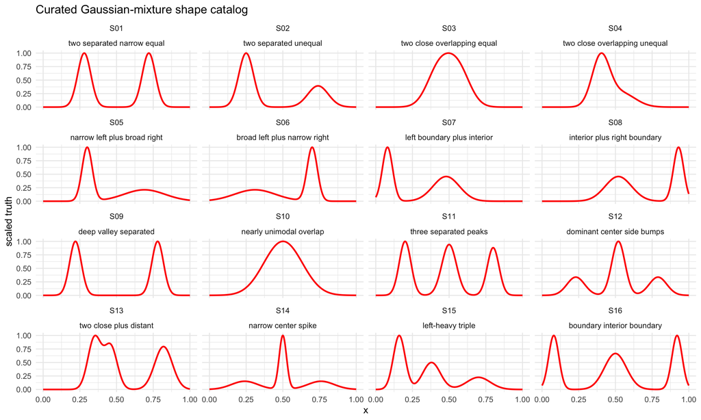

```r
x.grid <- seq(0, 1, length.out = 500)
shape.curves <- do.call(rbind, lapply(seq_len(nrow(shapes)), function(i) {
  data.frame(
    shape.id = shapes$shape.id[i],
    shape.name = shapes$shape.name[i],
    x = x.grid,
    truth = mixture_signal(x.grid, shapes$means[[i]], shapes$sds[[i]], shapes$weights[[i]])
  )
}))

ggplot(shape.curves, aes(x, truth)) +
  geom_line(color = "red", linewidth = 0.8) +
  facet_wrap(~ shape.id + shape.name, ncol = 4) +
  labs(title = "Curated Gaussian-mixture shape catalog", x = "x", y = "scaled truth") +
  theme_minimal(base_size = 10)
```

## 5 Model Grid

```r
metric.configs <- metric_grid()
metric.configs[, c("config.id", "config.label", "filter.type", "n.eigenpairs")]
```

```
##    config.id                        config.label filter.type n.eigenpairs
## 1        M01      inverse.length.power alpha=0.5 heat_kernel           60
## 2        M02        inverse.length.power alpha=1 heat_kernel           60
## 3        M03      inverse.length.power alpha=1.5 heat_kernel           60
## 4        M04        inverse.length.power alpha=2 heat_kernel           60
## 5        M05        inverse.length.power alpha=3 heat_kernel           60
## 6        M06             exp.length sigma=median heat_kernel           60
## 7        M07         exp.length sigma=edge.q0.75 heat_kernel           60
## 8        M08     exp.length.squared sigma=median heat_kernel           60
## 9        M09 exp.length.squared sigma=edge.q0.75 heat_kernel           60
## 10       M10       self.tuned.gaussian local.k=3 heat_kernel           60
## 11       M11       self.tuned.gaussian local.k=5 heat_kernel           60
## 12       M12      self.tuned.gaussian local.k=10 heat_kernel           60
```

## 6 Run Benchmark

The full fit table is generated outside this report by:

```r
Rscript dev/metric-graph-lowpass-benchmarks/compute_multi_scenario_1d_mixture_results.R
```

The report reads the precomputed table below.

```r
results.file <- file.path(
  repo.dir,
  "dev/metric-graph-lowpass-benchmarks/reports/multi_scenario_1d_mixture_results.csv"
)
if (!file.exists(results.file)) {
  stop("Missing precomputed results file. Run compute_multi_scenario_1d_mixture_results.R first.")
}
results <- read.csv(results.file, stringsAsFactors = FALSE)

data.frame(
  n.rows = nrow(results),
  n.datasets = length(unique(results$dataset.id)),
  n.metric.rows = sum(results$method == "fit.metric.graph.lowpass"),
  n.rdgraph.rows = sum(results$method == "fit.rdgraph.regression"),
  n.errors = sum(results$status != "ok"),
  results.file = results.file
)
```

```
##   n.rows n.datasets n.metric.rows n.rdgraph.rows n.errors
## 1   3120        240          2880            240        0
##                                                                                                             results.file
## 1 /Users/pgajer/current_projects/gflow/dev/metric-graph-lowpass-benchmarks/reports/multi_scenario_1d_mixture_results.csv
```

## 7 Overall Performance

```r
ok <- subset(results, status == "ok")
metric.ok <- subset(ok, method == "fit.metric.graph.lowpass")
rd.ok <- subset(ok, method == "fit.rdgraph.regression")

overall <- aggregate(
  rmse.truth ~ method,
  data = ok,
  FUN = function(z) c(median = median(z), q25 = quantile(z, 0.25),
                      q75 = quantile(z, 0.75), mean = mean(z))
)
do.call(data.frame, overall)
```

```
##                     method rmse.truth.median rmse.truth.q25.25.
## 1 fit.metric.graph.lowpass        0.03557598         0.03119997
## 2   fit.rdgraph.regression        0.08492993         0.05785426
##   rmse.truth.q75.75. rmse.truth.mean
## 1         0.04223217      0.03893215
## 2         0.10766837      0.08618547
```

```r
config.ranking <- aggregate(
  rmse.truth ~ config.id + config.label + method,
  data = metric.ok,
  FUN = function(z) c(median = median(z), mean = mean(z), q90 = quantile(z, 0.90))
)
config.ranking <- do.call(data.frame, config.ranking)
names(config.ranking) <- sub("rmse.truth.", "", names(config.ranking), fixed = TRUE)
config.ranking <- config.ranking[order(config.ranking$median), ]
head(config.ranking, 12)
```

```
##    config.id                        config.label                   method
## 1        M07         exp.length sigma=edge.q0.75 fit.metric.graph.lowpass
## 6        M02        inverse.length.power alpha=1 fit.metric.graph.lowpass
## 2        M06             exp.length sigma=median fit.metric.graph.lowpass
## 7        M03      inverse.length.power alpha=1.5 fit.metric.graph.lowpass
## 5        M01      inverse.length.power alpha=0.5 fit.metric.graph.lowpass
## 3        M09 exp.length.squared sigma=edge.q0.75 fit.metric.graph.lowpass
## 8        M04        inverse.length.power alpha=2 fit.metric.graph.lowpass
## 12       M11       self.tuned.gaussian local.k=5 fit.metric.graph.lowpass
## 10       M12      self.tuned.gaussian local.k=10 fit.metric.graph.lowpass
## 4        M08     exp.length.squared sigma=median fit.metric.graph.lowpass
## 11       M10       self.tuned.gaussian local.k=3 fit.metric.graph.lowpass
## 9        M05        inverse.length.power alpha=3 fit.metric.graph.lowpass
##        median       mean    q90.90.
## 1  0.03328835 0.03498683 0.04498668
## 6  0.03357479 0.03520096 0.04445271
## 2  0.03374114 0.03566151 0.04563541
## 7  0.03378997 0.03562286 0.04464639
## 5  0.03386303 0.03548293 0.04717560
## 3  0.03456051 0.03653667 0.04784791
## 8  0.03474756 0.03650542 0.04726284
## 12 0.03489511 0.03697970 0.04857651
## 10 0.03513137 0.03749797 0.05055862
## 4  0.03792248 0.04035352 0.05138283
## 11 0.03807476 0.03986933 0.05294198
## 9  0.04655362 0.06248808 0.06828086
```

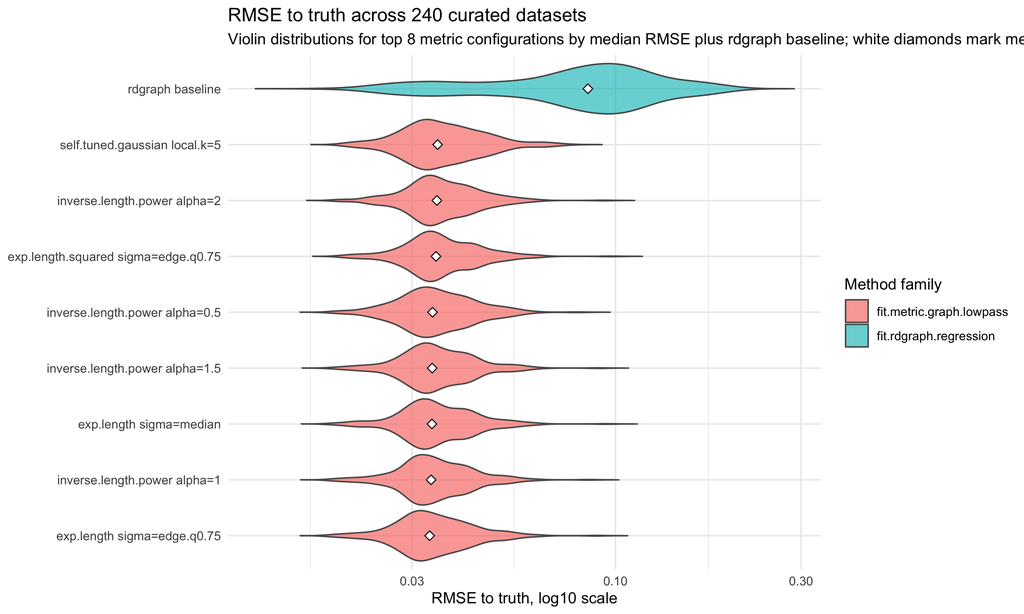

```r
plot.df <- ok
plot.df$display.method <- ifelse(
  plot.df$method == "fit.rdgraph.regression",
  "rdgraph baseline",
  plot.df$config.label
)
top.configs <- head(config.ranking$config.label, 8)
plot.df <- subset(plot.df, method == "fit.rdgraph.regression" | config.label %in% top.configs)

ggplot(plot.df, aes(x = reorder(display.method, rmse.truth, median), y = rmse.truth,
                    fill = method)) +
  geom_violin(scale = "width", trim = FALSE, alpha = 0.65, color = "gray35") +
  stat_summary(fun = median, geom = "point", shape = 23, size = 2.2,
               fill = "white", color = "black") +
  scale_y_log10() +
  coord_flip() +
  labs(
    title = "RMSE to truth across 240 curated datasets",
    subtitle = "Violin distributions for top 8 metric configurations by median RMSE plus rdgraph baseline; white diamonds mark medians",
    x = NULL,
    y = "RMSE to truth, log10 scale",
    fill = "Method family"
  ) +
  theme_minimal(base_size = 11)
```

## 8 Per-Scenario Winners

```r
best.metric.by.dataset <- metric.ok[order(metric.ok$dataset.id, metric.ok$rmse.truth), ]
best.metric.by.dataset <- best.metric.by.dataset[!duplicated(best.metric.by.dataset$dataset.id), ]
rd.by.dataset <- rd.ok[, c("dataset.id", "rmse.truth")]
names(rd.by.dataset)[2] <- "rdgraph.rmse.truth"
best.compare <- merge(best.metric.by.dataset, rd.by.dataset, by = "dataset.id", all.x = TRUE)
best.compare$metric.beats.rdgraph <- best.compare$rmse.truth < best.compare$rdgraph.rmse.truth

data.frame(
  datasets = nrow(best.compare),
  metric.beats.rdgraph = sum(best.compare$metric.beats.rdgraph, na.rm = TRUE),
  metric.beats.rdgraph.frac = mean(best.compare$metric.beats.rdgraph, na.rm = TRUE),
  median.best.metric.rmse = median(best.compare$rmse.truth, na.rm = TRUE),
  median.rdgraph.rmse = median(best.compare$rdgraph.rmse.truth, na.rm = TRUE)
)
```

```
##   datasets metric.beats.rdgraph metric.beats.rdgraph.frac
## 1      240                  228                      0.95
##   median.best.metric.rmse median.rdgraph.rmse
## 1              0.03204617          0.08492993
```

```r
winner.summary <- aggregate(
  metric.beats.rdgraph ~ variant.id + variant.name,
  data = best.compare,
  FUN = mean
)
winner.summary
```

```
##   variant.id                  variant.name metric.beats.rdgraph
## 1         V2 center-biased heteroskedastic               0.9375
## 2         V3   gap-biased laplace outliers               0.9625
## 3         V1              uniform gaussian               0.9500
```

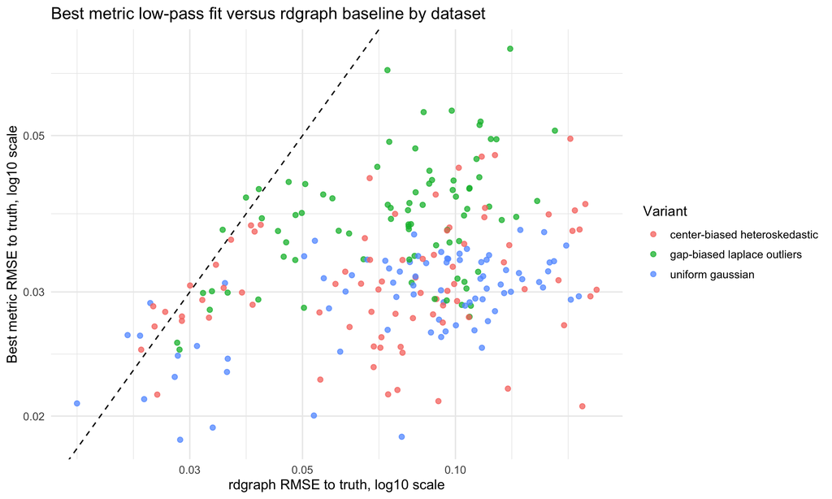

```r
ggplot(best.compare, aes(x = rdgraph.rmse.truth, y = rmse.truth, color = variant.name)) +
  geom_abline(slope = 1, intercept = 0, linetype = 2) +
  geom_point(alpha = 0.75, size = 1.8) +
  scale_x_log10() +
  scale_y_log10() +
  labs(
    title = "Best metric low-pass fit versus rdgraph baseline by dataset",
    x = "rdgraph RMSE to truth, log10 scale",
    y = "Best metric RMSE to truth, log10 scale",
    color = "Variant"
  ) +
  theme_minimal(base_size = 12)
```

## 9 Scenario and Noise Pattern Effects

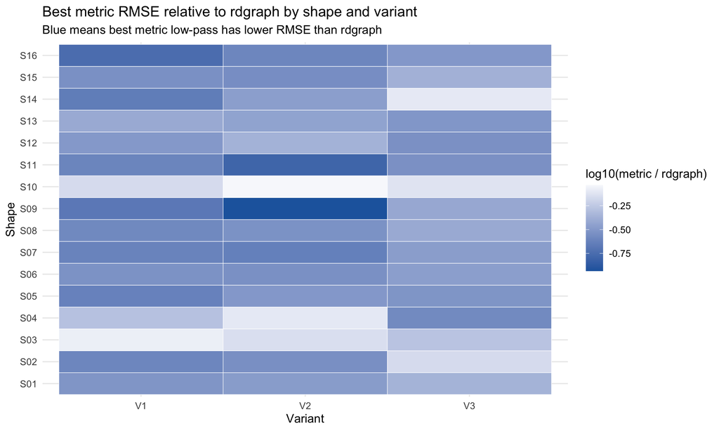

```r
shape.variant.summary <- aggregate(
  rmse.truth ~ shape.id + shape.name + variant.id + variant.name + method,
  data = ok,
  FUN = median
)
shape.variant.best.metric <- aggregate(
  rmse.truth ~ shape.id + shape.name + variant.id + variant.name,
  data = metric.ok,
  FUN = min
)
shape.variant.rd <- subset(shape.variant.summary, method == "fit.rdgraph.regression")
names(shape.variant.rd)[names(shape.variant.rd) == "rmse.truth"] <- "rdgraph.median.rmse"
shape.variant.compare <- merge(shape.variant.best.metric, shape.variant.rd,
                               by = c("shape.id", "shape.name", "variant.id", "variant.name"),
                               all.x = TRUE)
shape.variant.compare$log10.metric.over.rdgraph <- log10(shape.variant.compare$rmse.truth /
                                                           shape.variant.compare$rdgraph.median.rmse)

ggplot(shape.variant.compare,
       aes(x = variant.id, y = shape.id, fill = log10.metric.over.rdgraph)) +
  geom_tile(color = "white") +
  scale_fill_gradient2(low = "#2166ac", mid = "white", high = "#b2182b", midpoint = 0) +
  labs(
    title = "Best metric RMSE relative to rdgraph by shape and variant",
    subtitle = "Blue means best metric low-pass has lower RMSE than rdgraph",
    x = "Variant",
    y = "Shape",
    fill = "log10(metric / rdgraph)"
  ) +
  theme_minimal(base_size = 12)
```

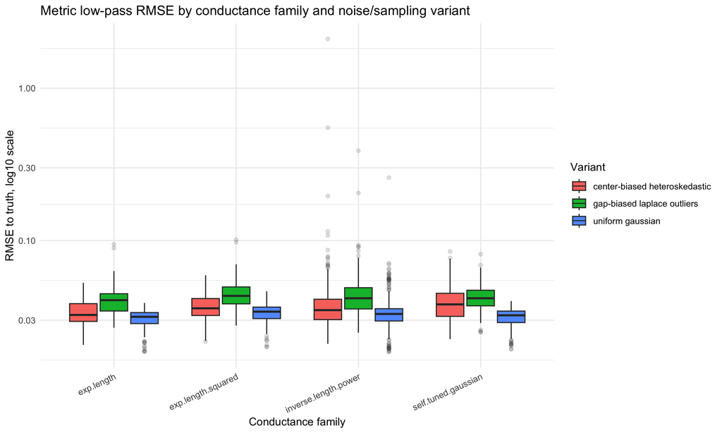

```r
metric.ok$conductance.family <- sub(" .*", "", metric.ok$config.label)
ggplot(metric.ok, aes(x = conductance.family, y = rmse.truth, fill = variant.name)) +
  geom_boxplot(outlier.alpha = 0.15) +
  scale_y_log10() +
  labs(
    title = "Metric low-pass RMSE by conductance family and noise/sampling variant",
    x = "Conductance family",
    y = "RMSE to truth, log10 scale",
    fill = "Variant"
  ) +
  theme_minimal(base_size = 11) +
  theme(axis.text.x = element_text(angle = 25, hjust = 1))
```

## 10 Example Fits

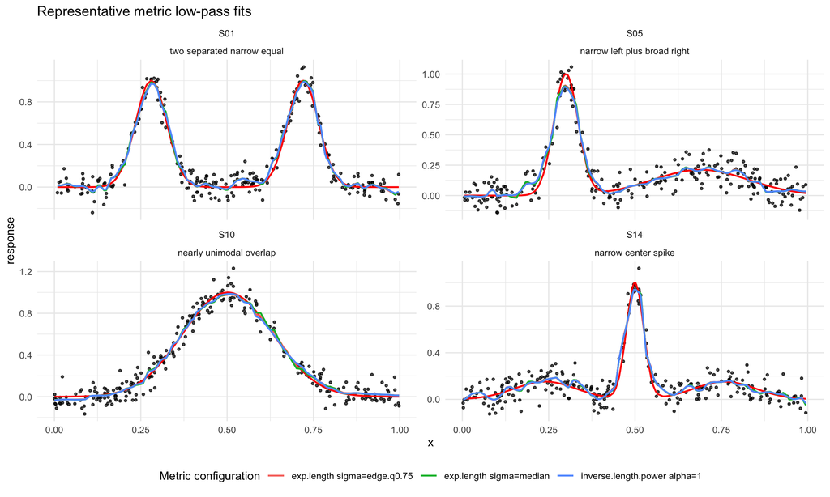

```r
example.scenarios <- subset(
  scenario.grid,
  replicate == 1L & variant.id == "V1" & shape.id %in% c("S01", "S05", "S10", "S14")
)
example.config.labels <- head(config.ranking$config.label, 3)
example.configs <- metric.configs[match(example.config.labels, metric.configs$config.label), ]

example.df <- do.call(rbind, lapply(seq_len(nrow(example.scenarios)), function(i) {
  shape <- shapes[match(example.scenarios$shape.id[i], shapes$shape.id), ]
  variant <- variants[match(example.scenarios$variant.id[i], variants$variant.id), ]
  dat <- make_dataset(shape, variant, example.scenarios$replicate[i], n = n)
  graph <- create.sknn.graph(dat$X, k = graph.k, connect.components = TRUE,
                             connect.method = "component.mst")
  do.call(rbind, lapply(seq_len(nrow(example.configs)), function(j) {
    spec <- example.configs[j, ]
    fit <- fit_metric_one(spec, graph, dat$y, n = n)$result
    if (inherits(fit, "error")) return(NULL)
    data.frame(
      dataset.id = example.scenarios$dataset.id[i],
      shape.id = example.scenarios$shape.id[i],
      shape.name = example.scenarios$shape.name[i],
      config.label = spec$config.label,
      x = dat$x,
      y = dat$y,
      truth = dat$truth,
      fitted = fit$fitted.values
    )
  }))
}))

if (!is.null(example.df) && nrow(example.df) > 0) {
  ggplot(example.df, aes(x, y)) +
    geom_point(color = "black", alpha = 0.35, size = 0.8) +
    geom_line(aes(y = truth), color = "red", linewidth = 0.7) +
    geom_line(aes(y = fitted, color = config.label), linewidth = 0.7) +
    facet_wrap(~ shape.id + shape.name, scales = "free_y", ncol = 2) +
    labs(
      title = "Representative metric low-pass fits",
      x = "x",
      y = "response",
      color = "Metric configuration"
    ) +
    theme_minimal(base_size = 10) +
    theme(legend.position = "bottom")
}
```

## 11 Runtime and Failures

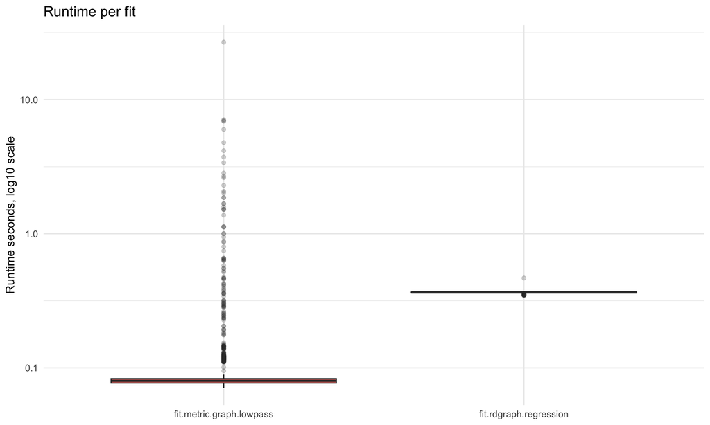

```r
ggplot(ok, aes(x = method, y = runtime.sec, fill = method)) +
  geom_boxplot(outlier.alpha = 0.2) +
  scale_y_log10() +
  labs(
    title = "Runtime per fit",
    x = NULL,
    y = "Runtime seconds, log10 scale"
  ) +
  theme_minimal(base_size = 12) +
  theme(legend.position = "none")
```

```r
failure.table <- subset(results, status != "ok")
if (nrow(failure.table) == 0) {
  data.frame(message = "No fit failures")
} else {
  aggregate(dataset.id ~ method + config.label + message, data = failure.table, FUN = length)
}
```

```
##           message
## 1 No fit failures
```

## 12 Full Result Location

The full result table was written to:

```r
file.path(repo.dir, "dev/metric-graph-lowpass-benchmarks/reports/multi_scenario_1d_mixture_results.csv")
```

```
## [1] "/Users/pgajer/current_projects/gflow/dev/metric-graph-lowpass-benchmarks/reports/multi_scenario_1d_mixture_results.csv"
```